# ML HW 2

Alex Osterbuhr

2023-04-09

## Part 1: Collect, Explore, Prepare the Data

### Problem 1

##### Import and preview the data. Call the dataset loans. Remember to use the tidyverse package as much as possible. This includes making use of the read_csv() functions when importing data. Use the glimpse() function to show that your data was imported properly

```r
library(tidyverse)
library(rpart)
library(rpart.plot)
library(caret)
library(performanceEstimation)
loans <- read_csv('https://s3.amazonaws.com/notredame.analytics.data/lendingclub.csv')
```

```r
glimpse(loans)
```

```
## Rows: 42,445
## Columns: 19
## $ LoanAmount       <dbl> 5000, 2500, 2400, 10000, 3000, 5000, 7000, 3000, 5600…
## $ LoanTerm         <dbl> 36, 60, 36, 36, 60, 36, 60, 36, 60, 60, 60, 36, 36, 3…
## $ InterestRate     <dbl> 10.65, 15.27, 15.96, 13.49, 12.69, 7.90, 15.96, 18.64…
## $ Installment      <dbl> 162.87, 59.83, 84.33, 339.31, 67.79, 156.46, 170.08, …
## $ Grade            <chr> "B", "C", "C", "C", "B", "A", "C", "E", "F", "B", "C"…
## $ EmploymentLength <chr> "10+ years", "< 1 year", "10+ years", "10+ years", "1…
## $ HomeOwnership    <chr> "RENT", "RENT", "RENT", "RENT", "RENT", "RENT", "RENT…
## $ AnnualIncome     <dbl> 24000.00, 30000.00, 12252.00, 49200.00, 80000.00, 360…
## $ IncomeVerified   <chr> "Yes", "Yes", "No", "Yes", "Yes", "Yes", "No", "Yes",…
## $ LoanPurpose      <chr> "credit_card", "car", "small_business", "other", "oth…
## $ DTI              <dbl> 27.65, 1.00, 8.72, 20.00, 17.94, 11.20, 23.51, 5.35, …
## $ Delinquencies    <dbl> 0, 0, 0, 0, 0, 0, 0, 0, 0, 0, 0, 0, 0, 0, 0, 0, 0, 0,…
## $ Inquiries        <dbl> 1, 5, 2, 1, 0, 3, 1, 2, 2, 0, 2, 0, 1, 2, 2, 1, 2, 0,…
## $ OpenAccounts     <dbl> 3, 3, 2, 10, 15, 9, 7, 4, 11, 2, 14, 12, 4, 11, 14, 1…
## $ TotalAccounts    <dbl> 9, 4, 10, 37, 38, 12, 11, 4, 13, 3, 23, 34, 9, 11, 29…
## $ PublicRecords    <dbl> 0, 0, 0, 0, 0, 0, 0, 0, 0, 0, 0, 0, 0, 0, 0, 0, 0, 0,…
## $ RevolvingCredit  <dbl> 13648, 1687, 2956, 5598, 27783, 7963, 17726, 8221, 52…
## $ CreditUtilized   <dbl> 83.70, 9.40, 98.50, 21.00, 53.90, 28.30, 85.60, 87.50…
## $ Default          <chr> "No", "Yes", "No", "No", "No", "No", "No", "No", "Yes…
```

### Problem 2

##### You notice that the Grade, EmploymentLength, HomeOwnership, IncomeVerified, LoanPurpose, and Default features were imported as string values. Convert these features to factors. Use the glimpse() function to show that your conversion worked

```r
loans <- loans %>%
  mutate(across(c(Grade,EmploymentLength, HomeOwnership, IncomeVerified, LoanPurpose, Default), ~as_factor(.)))

glimpse(loans)
```

```
## Rows: 42,445
## Columns: 19
## $ LoanAmount       <dbl> 5000, 2500, 2400, 10000, 3000, 5000, 7000, 3000, 5600…
## $ LoanTerm         <dbl> 36, 60, 36, 36, 60, 36, 60, 36, 60, 60, 60, 36, 36, 3…
## $ InterestRate     <dbl> 10.65, 15.27, 15.96, 13.49, 12.69, 7.90, 15.96, 18.64…
## $ Installment      <dbl> 162.87, 59.83, 84.33, 339.31, 67.79, 156.46, 170.08, …
## $ Grade            <fct> B, C, C, C, B, A, C, E, F, B, C, B, C, B, B, D, C, A,…
## $ EmploymentLength <fct> 10+ years, < 1 year, 10+ years, 10+ years, 1 year, 3 …
## $ HomeOwnership    <fct> RENT, RENT, RENT, RENT, RENT, RENT, RENT, RENT, OWN, …
## $ AnnualIncome     <dbl> 24000.00, 30000.00, 12252.00, 49200.00, 80000.00, 360…
## $ IncomeVerified   <fct> Yes, Yes, No, Yes, Yes, Yes, No, Yes, Yes, Yes, No, Y…
## $ LoanPurpose      <fct> credit_card, car, small_business, other, other, weddi…
## $ DTI              <dbl> 27.65, 1.00, 8.72, 20.00, 17.94, 11.20, 23.51, 5.35, …
## $ Delinquencies    <dbl> 0, 0, 0, 0, 0, 0, 0, 0, 0, 0, 0, 0, 0, 0, 0, 0, 0, 0,…
## $ Inquiries        <dbl> 1, 5, 2, 1, 0, 3, 1, 2, 2, 0, 2, 0, 1, 2, 2, 1, 2, 0,…
## $ OpenAccounts     <dbl> 3, 3, 2, 10, 15, 9, 7, 4, 11, 2, 14, 12, 4, 11, 14, 1…
## $ TotalAccounts    <dbl> 9, 4, 10, 37, 38, 12, 11, 4, 13, 3, 23, 34, 9, 11, 29…
## $ PublicRecords    <dbl> 0, 0, 0, 0, 0, 0, 0, 0, 0, 0, 0, 0, 0, 0, 0, 0, 0, 0,…
## $ RevolvingCredit  <dbl> 13648, 1687, 2956, 5598, 27783, 7963, 17726, 8221, 52…
## $ CreditUtilized   <dbl> 83.70, 9.40, 98.50, 21.00, 53.90, 28.30, 85.60, 87.50…
## $ Default          <fct> No, Yes, No, No, No, No, No, No, Yes, Yes, No, No, Ye…
```

### Problem 3

##### Get descriptive statistics for the entire dataset

```r
summary(loans)
```

```
##    LoanAmount       LoanTerm      InterestRate    Installment      Grade
##  Min.   :  500   Min.   :36.00   Min.   : 5.42   Min.   :  15.67   B:12376
##  1st Qu.: 5200   1st Qu.:36.00   1st Qu.: 9.63   1st Qu.: 165.74   C: 8719
##  Median : 9800   Median :36.00   Median :11.99   Median : 278.15   A:10171
##  Mean   :11103   Mean   :42.22   Mean   :12.16   Mean   : 322.98   E: 3380
##  3rd Qu.:15000   3rd Qu.:60.00   3rd Qu.:14.72   3rd Qu.: 428.64   F: 1294
##  Max.   :35000   Max.   :60.00   Max.   :24.59   Max.   :1305.19   D: 5996
##                                                                    G:  509
##   EmploymentLength  HomeOwnership    AnnualIncome     IncomeVerified
##  10+ years: 9365   RENT    :20126   Min.   :   1896   Yes:23754
##  < 1 year : 5029   OWN     : 3243   1st Qu.:  40000   No :18691
##  2 years  : 4736   MORTGAGE:18938   Median :  59000
##  3 years  : 4358   OTHER   :  134   Mean   :  69169
##  4 years  : 3640   NONE    :    4   3rd Qu.:  82500
##  1 year   : 3584                    Max.   :6000000
##  (Other)  :11733
##              LoanPurpose         DTI        Delinquencies       Inquiries
##  debt_consolidation:19759   Min.   : 0.00   Min.   : 0.0000   Min.   : 0.000
##  credit_card       : 5474   1st Qu.: 8.21   1st Qu.: 0.0000   1st Qu.: 0.000
##  other             : 4383   Median :13.48   Median : 0.0000   Median : 1.000
##  home_improvement  : 3194   Mean   :13.38   Mean   : 0.1525   Mean   : 1.081
##  major_purchase    : 2304   3rd Qu.:18.69   3rd Qu.: 0.0000   3rd Qu.: 2.000
##  small_business    : 1991   Max.   :29.99   Max.   :13.0000   Max.   :33.000
##  (Other)           : 5340
##   OpenAccounts    TotalAccounts   PublicRecords     RevolvingCredit
##  Min.   : 1.000   Min.   : 1.00   Min.   :0.00000   Min.   :      0
##  1st Qu.: 6.000   1st Qu.:13.00   1st Qu.:0.00000   1st Qu.:   3665
##  Median : 9.000   Median :20.00   Median :0.00000   Median :   8847
##  Mean   : 9.351   Mean   :22.14   Mean   :0.05819   Mean   :  14320
##  3rd Qu.:12.000   3rd Qu.:29.00   3rd Qu.:0.00000   3rd Qu.:  17268
##  Max.   :47.000   Max.   :90.00   Max.   :5.00000   Max.   :1207359
##
##  CreditUtilized   Default
##  Min.   :  0.00   No :36036
##  1st Qu.: 25.70   Yes: 6409
##  Median : 49.70
##  Mean   : 49.12
##  3rd Qu.: 72.70
##  Max.   :119.00
##
```

```r
head(loans)
```

```
## # A tibble: 6 × 19
##   LoanAm…¹ LoanT…² Inter…³ Insta…⁴ Grade Emplo…⁵ HomeO…⁶ Annua…⁷ Incom…⁸ LoanP…⁹
##      <dbl>   <dbl>   <dbl>   <dbl> <fct> <fct>   <fct>     <dbl> <fct>   <fct>
## 1     5000      36    10.6   163.  B     10+ ye… RENT      24000 Yes     credit…
## 2     2500      60    15.3    59.8 C     < 1 ye… RENT      30000 Yes     car
## 3     2400      36    16.0    84.3 C     10+ ye… RENT      12252 No      small_…
## 4    10000      36    13.5   339.  C     10+ ye… RENT      49200 Yes     other
## 5     3000      60    12.7    67.8 B     1 year  RENT      80000 Yes     other
## 6     5000      36     7.9   156.  A     3 years RENT      36000 Yes     wedding
## # … with 9 more variables: DTI <dbl>, Delinquencies <dbl>, Inquiries <dbl>,
## #   OpenAccounts <dbl>, TotalAccounts <dbl>, PublicRecords <dbl>,
## #   RevolvingCredit <dbl>, CreditUtilized <dbl>, Default <fct>, and abbreviated
## #   variable names ¹LoanAmount, ²LoanTerm, ³InterestRate, ⁴Installment,
## #   ⁵EmploymentLength, ⁶HomeOwnership, ⁷AnnualIncome, ⁸IncomeVerified,
## #   ⁹LoanPurpose
```

### Problem 4

##### Split your dataset into training and test sets using stratified random sampling (with Default as the stratum). Assign 75% of your original data to the training set and 25% to the test set. Call the training set, loans_train, and the test set, loans_test. Use ‘1234’ for your seed and don’t forget to use the RNGkind() function

```r
RNGkind(sample.kind = "Rounding")
set.seed(1234)
sample <- createDataPartition(loans$Default, p=.75, list = FALSE)
loans_train <- loans[sample, ]

loans_test <- loans[-sample, ]

loans_train %>%
  count(Default) %>%
  mutate(prop= round(n/ sum(n), 4)) %>%
  arrange(desc(n))
```

```
## # A tibble: 2 × 3
##   Default     n  prop
##   <fct>   <int> <dbl>
## 1 No      27027 0.849
## 2 Yes      4807 0.151
```

We see here that the training set is widely imbalanced and therefore the test set is as well.

### Problem 5

##### Based on the descriptive statistics of the loans dataset, you notice that the dataset suffers from class imbalance. Use the smote() function from the performanceEstimation package to balance (50-50) the training set. Use ‘1234’ for your seed here as well and don’t forget to use the RNGkind() function.

```r
RNGkind(sample.kind = 'Rounding')
set.seed(1234)
loans_train <- smote(Default ~ ., loans_train, perc.over = 1, perc.under = 2)

loans_train %>%
  count(Default) %>%
  mutate(prop= round(n/ sum(n), 4)) %>%
  arrange(desc(n))
```

```
## # A tibble: 2 × 3
##   Default     n  prop
##   <fct>   <int> <dbl>
## 1 No       9614   0.5
## 2 Yes      9614   0.5
```

After playing with different smote numbers, I found that using 1 as perc.over and 2 as perc.under gives us a 50/50 balance.

### Problem 6

##### During the recursive partitioning process, decision trees attempt to create a split using different values for a feature. You notice that the values for the Delinquencies, Inquiries, OpenAccounts, TotalAccounts, and PublicRecords features are double-precision values. This means that the decision tree could split on OpenAccounts <= 1.4. This makes no sense since a borrower cannot have 1.4 open accounts. To resolve this potential issue, convert these features to integers for both the training and test sets. Use the glimpse() function to show that your conversion worked.

```r
loans_test <- loans_test %>%
  mutate(across(c(Delinquencies, Inquiries, OpenAccounts, TotalAccounts, PublicRecords), ~as.integer(.)))

loans_train <- loans_train %>%
  mutate(across(c(Delinquencies, Inquiries, OpenAccounts, TotalAccounts, PublicRecords), ~as.integer(.)))

glimpse(loans_test)
```

```
## Rows: 10,611
## Columns: 19
## $ LoanAmount       <dbl> 2400, 10000, 3000, 5000, 3000, 5375, 12000, 3000, 100…
## $ LoanTerm         <dbl> 36, 36, 60, 36, 36, 60, 36, 36, 36, 60, 36, 60, 36, 3…
## $ InterestRate     <dbl> 15.96, 13.49, 12.69, 7.90, 18.64, 12.69, 12.69, 9.91,…
## $ Installment      <dbl> 84.33, 339.31, 67.79, 156.46, 109.43, 121.45, 402.54,…
## $ Grade            <fct> C, C, B, A, E, B, B, B, D, D, B, C, C, B, B, A, D, A,…
## $ EmploymentLength <fct> 10+ years, 10+ years, 1 year, 3 years, 9 years, < 1 y…
## $ HomeOwnership    <fct> RENT, RENT, RENT, RENT, RENT, RENT, OWN, RENT, RENT, …
## $ AnnualIncome     <dbl> 12252, 49200, 80000, 36000, 48000, 15000, 75000, 1500…
## $ IncomeVerified   <fct> No, Yes, Yes, Yes, Yes, Yes, Yes, Yes, No, No, Yes, Y…
## $ LoanPurpose      <fct> small_business, other, other, wedding, car, other, de…
## $ DTI              <dbl> 8.72, 20.00, 17.94, 11.20, 5.35, 18.08, 10.78, 12.56,…
## $ Delinquencies    <int> 0, 0, 0, 0, 0, 0, 0, 0, 0, 3, 0, 0, 0, 0, 0, 0, 0, 0,…
## $ Inquiries        <int> 2, 1, 0, 3, 2, 0, 0, 2, 1, 0, 0, 1, 1, 2, 0, 0, 0, 0,…
## $ OpenAccounts     <int> 2, 10, 15, 9, 4, 2, 12, 11, 11, 14, 8, 11, 6, 9, 7, 1…
## $ TotalAccounts    <int> 10, 37, 38, 12, 4, 3, 34, 11, 23, 22, 12, 31, 6, 12, …
## $ PublicRecords    <int> 0, 0, 0, 0, 0, 0, 0, 0, 0, 0, 0, 0, 0, 0, 0, 0, 0, 0,…
## $ RevolvingCredit  <dbl> 2956, 5598, 27783, 7963, 8221, 9279, 23336, 7323, 652…
## $ CreditUtilized   <dbl> 98.5, 21.0, 53.9, 28.3, 87.5, 36.5, 67.1, 43.1, 81.5,…
## $ Default          <fct> No, No, No, No, No, Yes, No, No, No, Yes, No, No, No,…
```

```r
glimpse(loans_train)
```

```
## Rows: 19,228
## Columns: 19
## $ LoanAmount       <dbl> 1500, 24250, 17500, 1500, 35000, 18000, 10000, 14000,…
## $ LoanTerm         <dbl> 36, 60, 36, 36, 60, 60, 36, 36, 36, 36, 36, 60, 36, 6…
## $ InterestRate     <dbl> 7.29, 23.91, 13.48, 10.99, 17.99, 13.06, 12.73, 7.51,…
## $ Installment      <dbl> 46.52, 519.76, 593.70, 49.11, 888.58, 410.11, 335.67,…
## $ Grade            <fct> A, G, C, B, E, C, C, A, A, B, B, B, A, A, A, E, A, C,…
## $ EmploymentLength <fct> < 1 year, 7 years, 10+ years, < 1 year, 9 years, 5 ye…
## $ HomeOwnership    <fct> RENT, MORTGAGE, MORTGAGE, RENT, RENT, RENT, MORTGAGE,…
## $ AnnualIncome     <dbl> 30000.0, 120000.0, 73200.0, 33996.0, 115000.0, 56000.…
## $ IncomeVerified   <fct> Yes, Yes, No, No, Yes, Yes, Yes, No, No, Yes, No, Yes…
## $ LoanPurpose      <fct> debt_consolidation, debt_consolidation, credit_card, …
## $ DTI              <dbl> 3.40, 12.96, 3.31, 16.13, 13.11, 23.25, 17.40, 18.44,…
## $ Delinquencies    <int> 0, 0, 0, 0, 0, 0, 1, 0, 0, 0, 0, 0, 0, 0, 0, 1, 0, 0,…
## $ Inquiries        <int> 0, 3, 0, 2, 0, 3, 0, 1, 1, 0, 0, 0, 1, 0, 0, 0, 0, 2,…
## $ OpenAccounts     <int> 3, 7, 4, 5, 12, 10, 8, 14, 8, 7, 12, 14, 11, 8, 13, 1…
## $ TotalAccounts    <int> 4, 20, 12, 14, 36, 20, 20, 43, 18, 13, 30, 39, 21, 16…
## $ PublicRecords    <int> 0, 0, 1, 0, 0, 0, 0, 0, 0, 1, 0, 0, 0, 0, 0, 0, 0, 0,…
## $ RevolvingCredit  <dbl> 1669, 31992, 9578, 3641, 13683, 15265, 29476, 12241, …
## $ CreditUtilized   <dbl> 11.9, 99.0, 37.0, 41.4, 48.2, 51.6, 57.6, 24.0, 6.0, …
## $ Default          <fct> No, No, No, No, No, No, No, No, No, No, No, No, No, N…
```

It would make more sense to go back to Problem 2 of this Part and convert these there so then it is one line of code instead of doing it for both the training and test sets.

## Part 2: Train the Model

### Problem 1

##### Train a model using the rpart() function from the rpart package. Set the complexity parameter to 0.005.

```r
loans_mod <- rpart(Default ~ ., loans_train, control = rpart.control(cp=.005) )
```

### Problem 2

##### Create a visualization of the decision tree model.

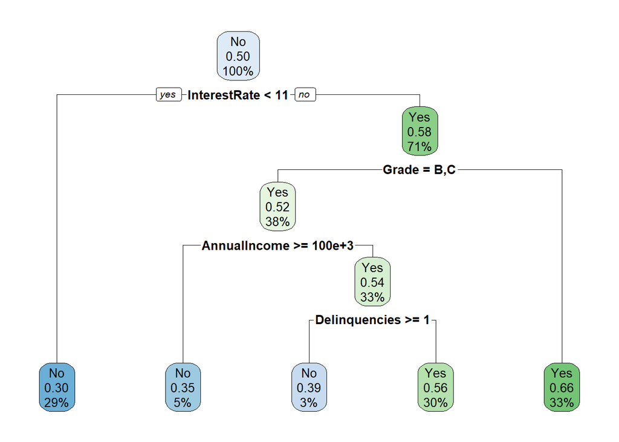

```r
loans_mod %>% rpart.plot()
```

### Problem 3

##### Based on the visualization, which feature is most predictive of whether a borrower will default or not default on their loan?

Interest Rate is the most predictive of whether a borrower will default or not based on this decision tree visualization. Note the 71% prediction if Interest Rate is greater than 11.It also has the highest variable importance of 50 as seen in the model summary.

```r
summary(loans_mod)
```

```
## Call:
## rpart(formula = Default ~ ., data = loans_train, control = rpart.control(cp = 0.005))
##   n= 19228
##
##           CP nsplit rel error    xerror        xstd
## 1 0.23028916      0 1.0000000 1.0170585 0.007210572
## 2 0.01466611      1 0.7697108 0.7698149 0.007017967
## 3 0.01372998      3 0.7403786 0.7462035 0.006975496
## 4 0.00500000      4 0.7266486 0.7310173 0.006945837
##
## Variable importance
##   InterestRate          Grade   AnnualIncome CreditUtilized  Delinquencies
##             50             35              4              4              2
##       LoanTerm    Installment     LoanAmount
##              2              1              1
##
## Node number 1: 19228 observations,    complexity param=0.2302892
##   predicted class=No   expected loss=0.5  P(node) =1
##     class counts:  9614  9614
##    probabilities: 0.500 0.500
##   left son=2 (5654 obs) right son=3 (13574 obs)
##   Primary splits:
##       InterestRate   < 10.75125 to the left,  improve=614.03860, (0 missing)
##       Grade          splits as  LRLRRRR, improve=555.08750, (0 missing)
##       LoanTerm       < 48       to the left,  improve=262.30150, (0 missing)
##       CreditUtilized < 46.10414 to the left,  improve=139.79190, (0 missing)
##       LoanPurpose    splits as  LLRRLRLLRRRRRR, improve= 98.30552, (0 missing)
##   Surrogate splits:
##       Grade          splits as  RRLRRRR, agree=0.886, adj=0.614, (0 split)
##       CreditUtilized < 22.32747 to the left,  agree=0.722, adj=0.054, (0 split)
##       Installment    < 32.705   to the left,  agree=0.707, adj=0.005, (0 split)
##       LoanPurpose    splits as  RLRRRRRRRRRRRR, agree=0.707, adj=0.004, (0 split)
##       DTI            < 28.73    to the right, agree=0.706, adj=0.002, (0 split)
##
## Node number 2: 5654 observations
##   predicted class=No   expected loss=0.3042094  P(node) =0.2940503
##     class counts:  3934  1720
##    probabilities: 0.696 0.304
##
## Node number 3: 13574 observations,    complexity param=0.01466611
```

[output cut: 50 more lines]

```
##       Delinquencies < 0.5      to the right, improve=30.66820, (0 missing)
##       LoanPurpose   splits as  LLRLLLLLLLLLRL, improve=28.60069, (0 missing)
##       LoanTerm      < 48       to the left,  improve=27.98894, (0 missing)
##       InterestRate  < 10.94711 to the right, improve=23.39921, (0 missing)
##       AnnualIncome  < 69984.83 to the right, improve=14.74687, (0 missing)
##
## Node number 26: 586 observations
##   predicted class=No   expected loss=0.387372  P(node) =0.03047639
##     class counts:   359   227
##    probabilities: 0.613 0.387
##
## Node number 27: 5714 observations
##   predicted class=Yes  expected loss=0.4427721  P(node) =0.2971708
##     class counts:  2530  3184
##    probabilities: 0.443 0.557
```

## Part 3: Evaluate the Model

### Problem 1

##### Using the model that you created in the previous section, predict the outcomes of the loans in the test dataset. Preview the first 5 predictions

```r
loans_pred <- predict(loans_mod, loans_test)
head(loans_pred, 5)
```

```
##          No       Yes
## 1 0.4427721 0.5572279
## 2 0.4427721 0.5572279
## 3 0.4427721 0.5572279
## 4 0.6957906 0.3042094
## 5 0.3447625 0.6552375
```

In my opinion, none of these predictions are good. Ultimately, this model would need refined.

### Problem 2

##### Add a new column to the loans_test dataset with the predicted outcome for each loan. Call the new column Prediction. Use the glimpse() function to show that the column was added.

```r
ideal <- .5
loans_test <- loans_test %>% mutate(Prediction = loans_pred[ ,2])

loans_test$Prediction <- ifelse(loans_test$Prediction>=ideal, "Yes", "No")

loans_test <- loans_test %>% mutate(Prediction = as_factor(Prediction))

glimpse(loans_test)
```

```
## Rows: 10,611
## Columns: 20
## $ LoanAmount       <dbl> 2400, 10000, 3000, 5000, 3000, 5375, 12000, 3000, 100…
## $ LoanTerm         <dbl> 36, 36, 60, 36, 36, 60, 36, 36, 36, 60, 36, 60, 36, 3…
## $ InterestRate     <dbl> 15.96, 13.49, 12.69, 7.90, 18.64, 12.69, 12.69, 9.91,…
## $ Installment      <dbl> 84.33, 339.31, 67.79, 156.46, 109.43, 121.45, 402.54,…
## $ Grade            <fct> C, C, B, A, E, B, B, B, D, D, B, C, C, B, B, A, D, A,…
## $ EmploymentLength <fct> 10+ years, 10+ years, 1 year, 3 years, 9 years, < 1 y…
## $ HomeOwnership    <fct> RENT, RENT, RENT, RENT, RENT, RENT, OWN, RENT, RENT, …
## $ AnnualIncome     <dbl> 12252, 49200, 80000, 36000, 48000, 15000, 75000, 1500…
## $ IncomeVerified   <fct> No, Yes, Yes, Yes, Yes, Yes, Yes, Yes, No, No, Yes, Y…
## $ LoanPurpose      <fct> small_business, other, other, wedding, car, other, de…
## $ DTI              <dbl> 8.72, 20.00, 17.94, 11.20, 5.35, 18.08, 10.78, 12.56,…
## $ Delinquencies    <int> 0, 0, 0, 0, 0, 0, 0, 0, 0, 3, 0, 0, 0, 0, 0, 0, 0, 0,…
## $ Inquiries        <int> 2, 1, 0, 3, 2, 0, 0, 2, 1, 0, 0, 1, 1, 2, 0, 0, 0, 0,…
## $ OpenAccounts     <int> 2, 10, 15, 9, 4, 2, 12, 11, 11, 14, 8, 11, 6, 9, 7, 1…
## $ TotalAccounts    <int> 10, 37, 38, 12, 4, 3, 34, 11, 23, 22, 12, 31, 6, 12, …
## $ PublicRecords    <int> 0, 0, 0, 0, 0, 0, 0, 0, 0, 0, 0, 0, 0, 0, 0, 0, 0, 0,…
## $ RevolvingCredit  <dbl> 2956, 5598, 27783, 7963, 8221, 9279, 23336, 7323, 652…
## $ CreditUtilized   <dbl> 98.5, 21.0, 53.9, 28.3, 87.5, 36.5, 67.1, 43.1, 81.5,…
## $ Default          <fct> No, No, No, No, No, Yes, No, No, No, Yes, No, No, No,…
## $ Prediction       <fct> Yes, Yes, Yes, No, Yes, Yes, Yes, No, Yes, Yes, Yes, …
```

```r
loans_test %>%
  summarise(Accuracy = sum(Default == Prediction)/ n())
```

```
## # A tibble: 1 × 1
##   Accuracy
##      <dbl>
## 1    0.534
```

This is not accurate enough. Perhaps if I used a different ideal cutoff in the previous problem, this could be more accurate?

## Part 4: Interpret the Reslults

#### Assuming that the Prediction column in loans_test is what your model predicts will happen, while the Default column is what actually happened, answer the following questions

### Problem 1

##### On average, for every loan that is paid back in full, LendingClub earns 12% of the original loan amount as profit. With this information, how much money did LendingClub make on the loans that were issued and paid back in full?

```r
profit <- loans_test %>% subset(Default=='No')

profit_amt <- sum(profit$LoanAmount * .12)
print(profit_amt)
```

```
## [1] 11866146
```

LendingClub seemed to realize a profit of $11,866,146 taking into account the 12% of each loan paid in full on the real No Defaults.

### Problem 2

##### On average, LendingClub loses 70% of the original loan amount, for every loan that was issued and not paid back in full. How much money did LendingClub lose as a result of bad loans that were issued based on the recommendation of your model?

```r
loss <- loans_test %>% subset(Prediction == 'No' & Default == 'Yes')
loss_amt <- sum(loss$LoanAmount * .7)
print(loss_amt)
```

```
## [1] 2784828
```

### Problem 3

##### Assuming that LendingClub incurs a loan servicing cost of 2% (of the original loan amount) for every loan that it issues, did LendingClub realize a profit or a loss based on your model? Make sure to show your work as code.

```r
service_cost <-sum(loans_test$LoanAmount * .02)

realization <- profit_amt - service_cost - loss_amt
print(realization)
```

```
## [1] 6733054
```

LendingClub realized a profit after subtracting the bad loans my model predicted and the service cost from the overall profit in Problem 1.

### Problem 4

##### What about the opportunity cost? How much money would LendingClub have made from loans that your model suggested were bad but were actually good?

```r
opp <- loans_test %>% subset(Default == 'No' & Prediction == 'Yes')

opp_cost <- sum(opp$LoanAmount * .12) - sum(opp$LoanAmount * .02)
print(opp_cost)
```

```
## [1] 5381460
```